# Omniture Log Files

David Milmont

June 13, 2016

# Loading the Data

Omniture logs are seperated out by day and in tab seperated format. You can combine multiple days into one file for analysis by using the windows command line utility. Place your seperate files into a folder that is easy to navigate to. I placed mine in C:

I then open windows command line and type in the following:

this will bring you to the root directory cd /

This brings you to the Data folder cd /Data

this is the command to combine the .tsv files. Any .tsv file will be combined and a new .tsv with the name of all.tsv will be created. copy *.tsv all.tsv

This is where you point R to the .tsv file which contains omniture logs. This turns the .tsv into a R dataframe which can be further manipulated for analysis without crashing your computer like Excel would. You can point to any file for R to work with. You do not want your file to be larger than your available system memory as all dataframes are loaded into memory.

```r
fileLocation <- 'c://data/01-ria.mt_2016-05-01.tsv'

#load the data
data <- read.csv(file=fileLocation, header = FALSE, sep = '\t')

#remove blank columns
data <- Filter(function(x)!all(is.na(x)), data)
```

## SQL on the dataframe

This is where you define the SQL to be ran against the dataframe. This will create a new dataframe called sqloutput where you can view your results.

```r
#define the sql ---------------------------
sqlOutput <- sqldf('


SELECT
V6 AS Domain
,COUNT(*) AS numOfOccurances

FROM data

GROUP BY V6
ORDER BY COUNT(*) DESC
LIMIT 5


                  ')
```

# SQL output

This is what your sqlOutput dataframe looks like after running the sql block

```
##          Domain numOfOccurances
## 1   comcast.net           24345
## 2        rr.com           12425
## 3   verizon.net            6428
## 4 sbcglobal.net            5915
## 5  t-mobile.com            5857
```

## Visualize your results

This should display the top 5 Domains in a nice bar chart with the color gradient being determined by count of occurances.

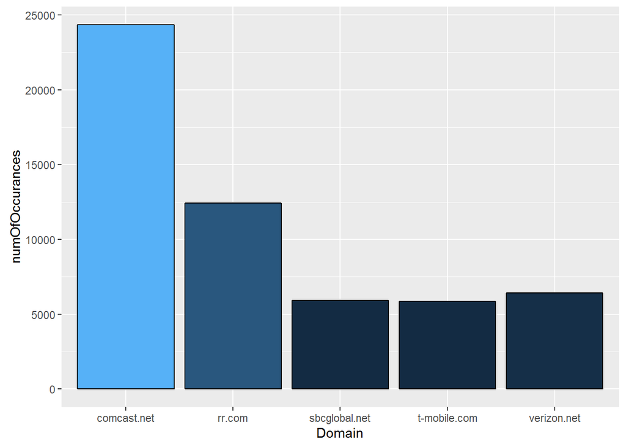

```r
ggplot(data=sqlOutput, aes(x=Domain, y=numOfOccurances, fill=numOfOccurances)) +
  geom_bar(colour="black", stat="identity") +
  guides(fill=FALSE)
```